# Paterson Public School District — NJ School Data Almanac – NJ District Profiles

NJ School Data Almanac

Paterson Public School District

PASSAIC COUNTY · TRADITIONAL PUBLIC DISTRICT · DFG A · 21,849 STUDENTS (2026)

21,849

Students

76.7%

4-yr grad rate

23.7%

Gr 3-8 ELA

35.7%

Chronically absent

$20,672

Per pupil

*10 things the data says about Paterson Public School District. Every figure is computed from New Jersey Department of Education data via the njschooldata package — nothing is estimated. Comparisons use District Factor Group (DFG) peers (39 districts in DFG A).*

No. 1 ACHIEVEMENT

## Paterson’s Elementary Reading Scores Never Bounced Back: 23.7% Proficient in 2024 vs 32.8% Before COVID

Five years after the pandemic, grade 3-8 reading proficiency remains nine points below its 2019 level and has barely moved since the shutdown.

Across New Jersey, schools have spent years working to undo pandemic learning loss. In Paterson’s elementary and middle schools, the recovery has yet to arrive. On the NJSLA exams given in grades 3 through 8, ELA proficiency stood at 23.7% in 2024, almost exactly where it landed when testing resumed in 2022 at 24.3% and ticked to 24.7% in 2023. The pre-pandemic mark was far higher: 32.8% proficient in 2019.

That leaves a gap of more than eight percentage points that has not closed in three rounds of testing. The drop from 2019 to 2022 was 8.5 points, and the two years since have erased essentially none of it. Math tells a similar story, sliding from 19.7% proficient in 2019 to 10.2% in 2022 before crawling back to only 12.9% by 2024 — still nearly seven points under the pre-COVID level.

These are the foundational years, when students learn to read fluently and master the arithmetic that later coursework assumes. A class that was in third grade in 2022 is now approaching middle school still carrying that deficit. With the youngest grades showing no rebound while high schoolers post gains, what is preventing Paterson’s elementary and middle schools from recovering the ground they lost?

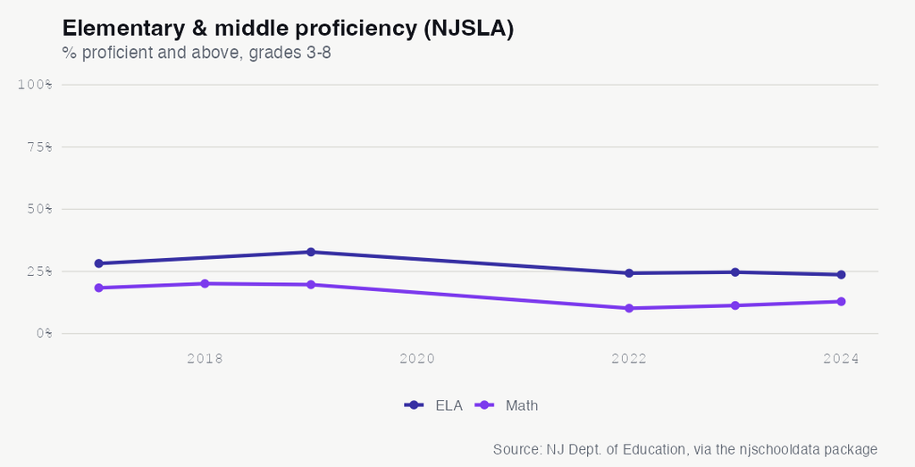

See the underlying data ›

No. 2 ACHIEVEMENT

## A Two-Speed Recovery in Paterson: High School Test Scores Jumped While Grades 3-8 Stayed Flat

NJGPA math proficiency for high schoolers leapt to 18.6% in 2025, but grade 3-8 NJSLA math sat at 12.9% with no rebound.

Paterson’s two main testing programs are moving in opposite directions. On the high-school NJGPA, math proficiency jumped to 18.6% in 2025, up from 11.2% in 2024 and 11.3% in 2023 — a gain of more than seven points after two flat years. ELA on the same exam rose to 44.8%, from 37.9% the year before. By those measures, the district’s oldest students are climbing.

The younger grades are not. On the NJSLA exams in grades 3 through 8, math proficiency was 12.9% in 2024, barely above the 10.2% recorded when testing resumed in 2022, and ELA held at 23.7%. Where the high school surged, the elementary and middle grades stalled.

The divergence matters because today’s elementary students are tomorrow’s NJGPA test-takers. If grade 3-8 proficiency stays near current levels, the high-school gains may prove hard to sustain as weaker cohorts move up. Is Paterson’s high-school improvement a durable trend, or a bright spot resting on a foundation that has not yet been repaired?

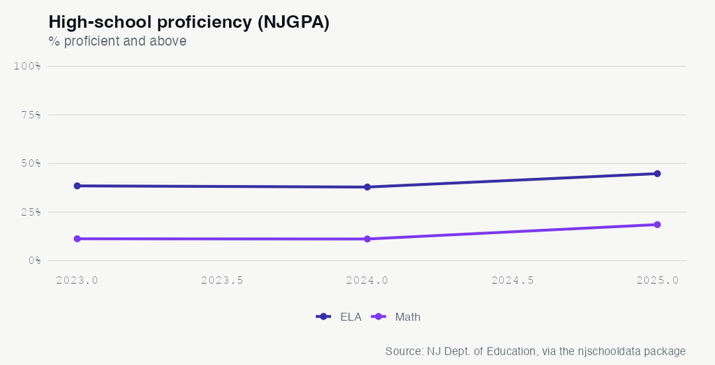

See the underlying data ›

No. 3 DEMOGRAPHICS

## Two in Five Paterson Students Are Now Multilingual Learners, Up From One in Seven a Decade Ago

The share of students learning English climbed from 15.2% in 2015 to 40.5% in 2026, even as the district shrank.

Paterson Public Schools is being remade by language. In 2015, 3,803 students, or 15.2% of enrollment, were classified as multilingual learners still acquiring English. By 2026 that figure had reached 8,849 students, or 40.5% of the district. The count of multilingual learners more than doubled while total enrollment fell by nearly 3,200.

The rise was steady and accelerating: the share crossed 20% in 2019, 24.8% in 2023, then jumped to 34.6% in 2025 and 40.5% in 2026 — a roughly six-percentage-point gain in a single year. In a district that lost students overall, multilingual learners were the one group growing fast enough to reshape the classroom.

That shift collides directly with the achievement data: on the 2024 grade 3-8 reading exam, students currently learning English scored 3.3% proficient. As multilingual learners approach a near-majority of enrollment, can Paterson staff bilingual and ESL programs fast enough to lift outcomes for the fastest-growing group in its schools?

[figure not shown]

See the underlying data ›

No. 4 EQUITY

## Paterson’s Reading Gap Runs 49 Points Wide: 52% of Asian Students Proficient vs 3% of English Learners

On the 2024 grade 3-8 ELA exam, proficiency ranged from 52.2% for Asian students down to single digits for students with disabilities and English learners.

Paterson’s 23.7% districtwide reading proficiency in grades 3 through 8 conceals dramatically different results from group to group. Asian students reached 52.2% proficient and white students 45.2% — both roughly double the district average. Hispanic students, who make up nearly three-quarters of the district, came in at 20.9%, and Black students at 17.5%.

The floor is far lower. Students receiving special education services scored 4.7% proficient in reading, and students currently learning English scored 3.3%. The distance between the top group and the bottom is nearly 49 percentage points. Students who are economically disadvantaged (23.9%) scored essentially the same as their non-disadvantaged peers (23.3%), so the widest divides here run along language and disability lines rather than income.

These are the two groups Paterson is adding fastest — multilingual learners are now 40.5% of enrollment — yet they sit furthest from grade level. What targeted reading support reaches the students who need it most, and is it scaling as quickly as their numbers are?

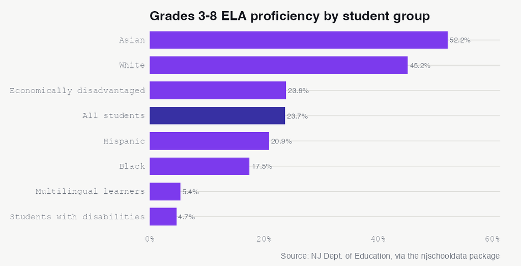

See the underlying data ›

No. 5 ENROLLMENT

## Paterson’s Enrollment Fell to 21,849 in 2026, Its Lowest on Record After Losing 4,218 Students Since 2023

Three straight years of declines erased a post-pandemic rebound and pushed enrollment 12.7% below its 2015 level.

Paterson enrolled 21,849 students in 2026, the smallest student body in the district’s recorded history. The drop was steep and recent: enrollment peaked at 26,067 in 2023 before falling 1,977 in 2024, 481 in 2025, and 1,760 in 2026 — a combined loss of 4,218 students, or roughly 16%, in three years.

The decline runs deeper than the pandemic. Between 2019 and 2022, enrollment slipped just 365 students, a 1.5% COVID-era dip. The sharper erosion came afterward, leaving 2026 enrollment 3,189 students, or 12.7%, below where the district stood in 2015.

Enrollment drives state aid and staffing, and Paterson’s path has been anything but smooth, swinging from a 6.4% jump in 2023 to a 7.6% drop the very next year. What is pulling thousands of students out of one of New Jersey’s largest districts, and is the slide finished?

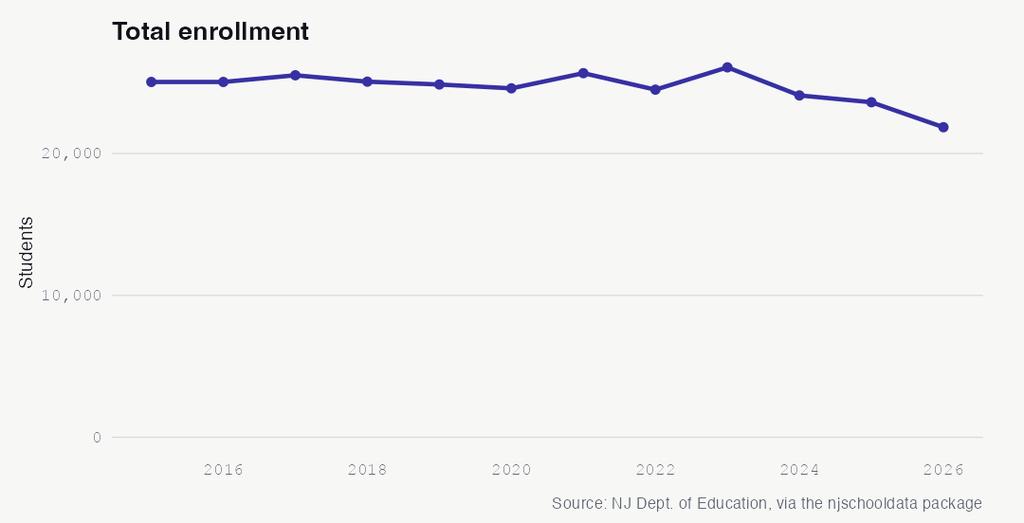

See the underlying data ›

No. 6 GRADUATION

## Paterson’s Graduation Rate of 76.7% Ranks in the Bottom Sixth of Its Peer Districts

The district’s 2025 four-year rate sits more than eight points below the median of its 39 District Factor Group A peers.

Paterson graduated 76.7% of its 2025 cohort of 1,634 students on time, placing it at the 15th percentile among the 39 high-need districts in its District Factor Group. The peer median was 85.0% — more than eight percentage points higher.

The rate has also slipped from its own recent peak. Paterson reached 83.7% in 2022, then fell to 75.2% in 2024 before edging back to 76.7% in 2025. The recent cohorts have been smaller too, dropping from 1,781 graduates-in-progress in 2020 to 1,634 in 2025, mirroring the district’s broader enrollment decline.

Graduation is the clearest single measure families use to judge a high school, and Paterson is lagging districts that serve similarly high-poverty communities. What is keeping the district roughly eight points behind peers facing comparable challenges?

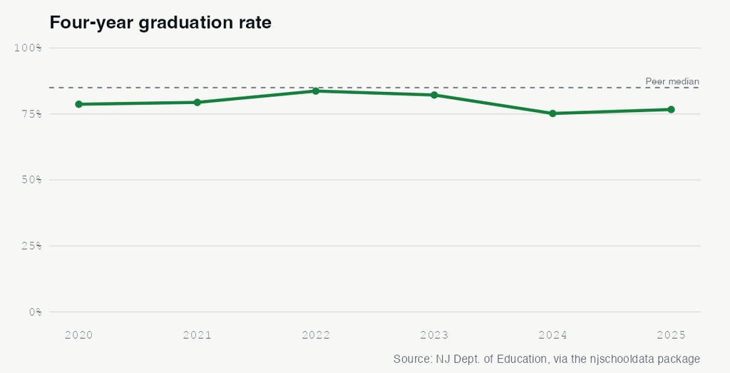

See the underlying data ›

No. 7 ATTENDANCE

## More Than a Third of Paterson Students Were Chronically Absent in 2024, vs 24% in Peer Districts

Chronic absenteeism eased from a pandemic peak of 49.6% but stayed well above both peers and pre-COVID levels.

In 2024, 35.7% of Paterson students were chronically absent, meaning they missed at least 10% of school days. That rate was more than eleven points above the District Factor Group A peer median of 24.1%, and well above the district’s own pre-pandemic mark of 27.6% in 2019.

The trajectory shows real recovery alongside lingering damage. Chronic absenteeism climbed to 49.6% in 2022, then fell to 41.6% in 2023 and 35.7% in 2024 — improving by roughly fourteen points over two years. But it has not returned to the 27.6% baseline the district posted before schools closed.

Absenteeism is tightly linked to achievement, and Paterson’s stalled grade 3-8 scores have unfolded against this backdrop of students missing weeks of class. With the rate still falling, can the district drive it back below the pre-COVID level, or has chronic absence settled at a higher new normal?

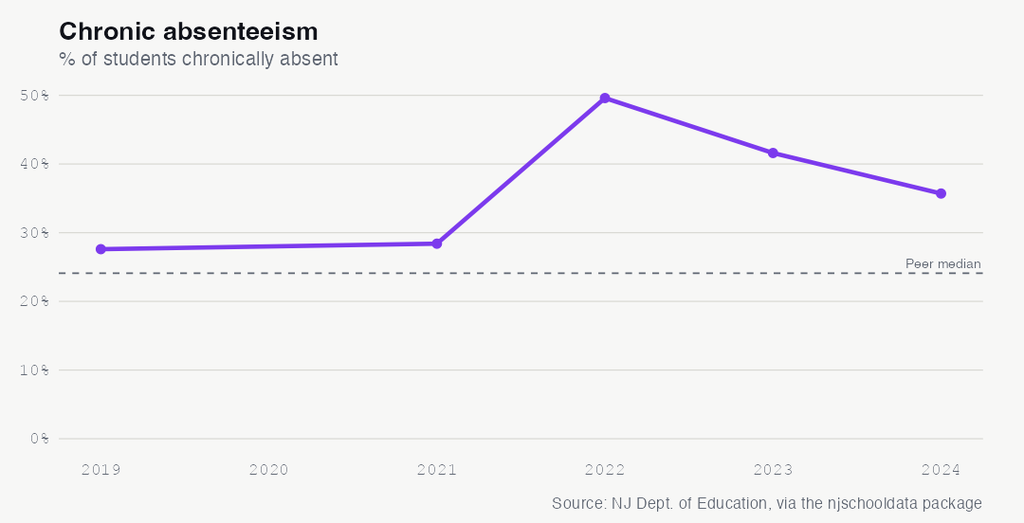

See the underlying data ›

No. 8 EQUITY

## Students With Disabilities Graduated at 64.7% in Paterson, 12 Points Below the District Average

Paterson’s 2025 graduation rate masked wide gaps between groups of students. Students with disabilities graduated at 64.7%, and students experiencing homelessness at 67.9% — both well below the district’s overall 76.7%. At the other end, Asian students graduated at 83.1% and white students at 81.7%.

Race and gender gaps were narrower but still visible. Black students graduated at 73.7% and Hispanic students at 76.7%, while female students (80.0%) outpaced male students (73.7%) by more than six points. Students who are economically disadvantaged — 1,300 of the cohort’s 1,634 students — graduated at 77.8%, just above the district average.

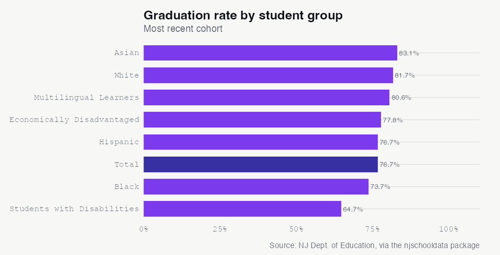

See the underlying data ›

No. 9 FINANCE

## Paterson’s Per-Pupil Spending Rose 38.5% Since 2014 to $20,672, Above the Peer Median

Spending climbed past most DFG A peers even as the number of students it supports kept shrinking.

Paterson spent $20,672 per pupil in 2024, up 38.5% from $14,930 a decade earlier in 2014. That figure landed at the 67th percentile among its District Factor Group A peers, above the peer median of $19,338. The district’s per-pupil spending climbed every year from 2017 onward.

More money per student in a high-poverty district raises the stakes on results. With spending now above the peer median but graduation trailing peers and grade 3-8 proficiency flat, what return is Paterson getting on each additional dollar?

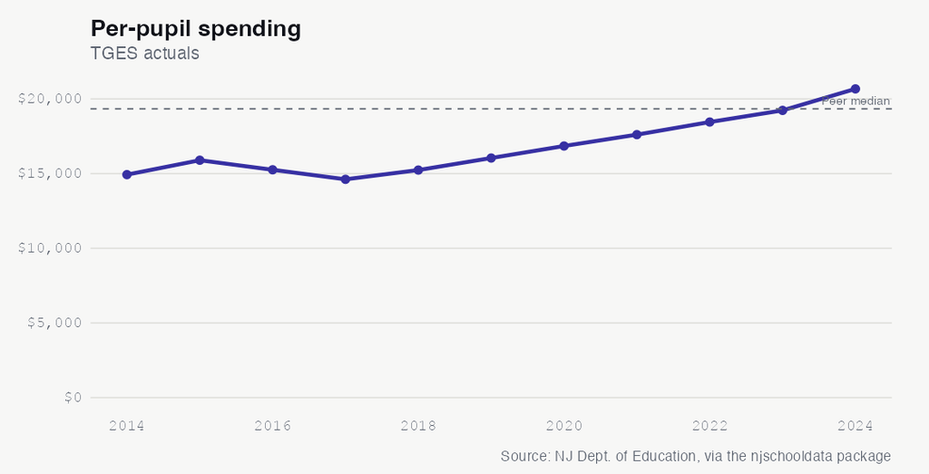

See the underlying data ›

No. 10 DEMOGRAPHICS

## Paterson’s Black Enrollment Share Slid From 21.4% to 15.8% as Hispanic and Asian Shares Grew

A decade of demographic change cut the Black share by 5.6 points while Hispanic enrollment rose to nearly three-quarters of the district.

The composition of Paterson’s student body shifted markedly over the past decade. The Black share of enrollment fell from 21.4% in 2015 to 15.8% in 2026, a drop of 5.6 percentage points and the district’s largest demographic change. Most of that decline came recently, with the Black share sliding from 19.2% in 2023 to 15.8% in 2026.

At the same time, Hispanic enrollment grew from 69.1% to 73.1%, and the Asian share nearly doubled from 3.4% to 6.6%. The white share has stayed small throughout, ending at 4.1% in 2026.

Demographic shifts of this scale change which families a district serves and which community institutions feel represented in its schools. As Paterson’s Black enrollment continues to contract, how will the district maintain culturally responsive supports for a group whose presence has dropped by more than a quarter in ten years?

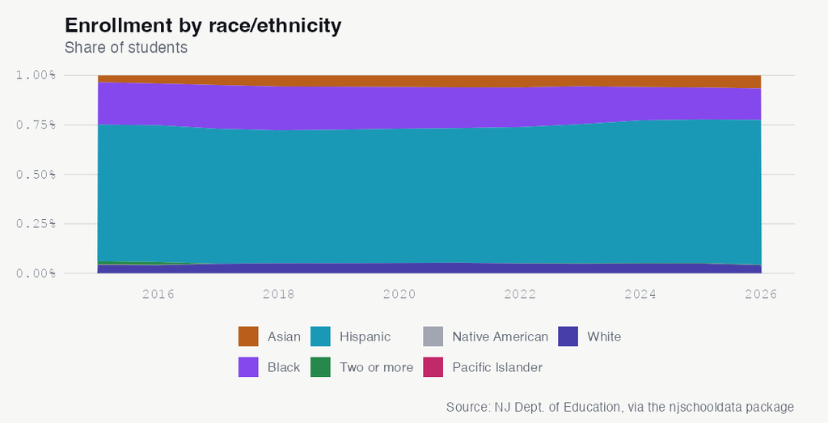

See the underlying data ›

## The Almanac

The full longitudinal record behind the stories above. Every number a reader can check.

### Enrollment (total)

| year | students | yoy | yoy_pct |
| --- | --- | --- | --- |
| 2015 | 25038 | NA | NA |
| 2016 | 25038 | 0 | 0 |
| 2017 | 25509 | 471 | 1.9 |
| 2018 | 25059 | -450 | -1.8 |
| 2019 | 24860 | -199 | -0.8 |
| 2020 | 24588 | -272 | -1.1 |
| 2021 | 25657 | 1069 | 4.3 |
| 2022 | 24495 | -1162 | -4.5 |
| 2023 | 26067 | 1572 | 6.4 |
| 2024 | 24090 | -1977 | -7.6 |
| 2025 | 23609 | -481 | -2 |
| 2026 | 21849 | -1760 | -7.5 |

### Demographic share (%) by year

| end_year | white | black | hispanic | asian | native_american | pacific_islander | multiracial |
| --- | --- | --- | --- | --- | --- | --- | --- |
| 2015 | 4.2 | 21.4 | 69.1 | 3.4 | 0.1 | 0.1 | 1.7 |
| 2016 | 4 | 21.1 | 69.1 | 4.1 | 0.1 | 0.1 | 1.5 |
| 2017 | 4.7 | 22.1 | 68.2 | 4.9 | 0 | 0.1 | 0 |
| 2018 | 5.1 | 22.2 | 67.1 | 5.6 | 0 | 0 | 0 |
| 2019 | 5.1 | 21.7 | 67.5 | 5.7 | 0 | 0 | 0 |
| 2020 | 5.2 | 21.1 | 67.8 | 5.9 | 0 | 0 | 0 |
| 2021 | 5.3 | 20.6 | 68 | 6 | 0 | 0 | 0 |
| 2022 | 5 | 20 | 68.8 | 6.1 | 0 | 0 | 0.1 |
| 2023 | 4.8 | 19.2 | 70.3 | 5.5 | 0 | 0 | 0.2 |
| 2024 | 4.9 | 16.8 | 72.1 | 5.9 | 0 | 0 | 0.3 |
| 2025 | 4.9 | 16.2 | 72.5 | 6.1 | 0 | 0 | 0.3 |
| 2026 | 4.1 | 15.8 | 73.1 | 6.6 | 0 | 0 | 0.3 |

### Special populations (LEP, FRL)

| end_year | subgroup | students | pct |
| --- | --- | --- | --- |
| 2015 | lep | 3803 | 15.2 |
| 2015 | free_reduced_lunch | 14309 | 57.1 |
| 2016 | lep | 4001 | 16.0 |
| 2016 | free_reduced_lunch | 18093 | 72.3 |
| 2017 | lep | 4350 | 17.1 |
| 2017 | free_reduced_lunch | 19139 | 75.0 |
| 2018 | lep | 4780 | 19.1 |
| 2018 | free_reduced_lunch | 19110 | 76.3 |
| 2019 | lep | 5047 | 20.3 |
| 2019 | free_reduced_lunch | 17057 | 68.6 |
| 2020 | lep | 5434 | 22.1 |
| 2020 | free_reduced_lunch | 18343 | 74.6 |
| 2021 | lep | 5542 | 21.6 |
| 2021 | free_reduced_lunch | 15856 | 61.8 |
| 2022 | lep | 5683 | 23.2 |
| 2022 | free_reduced_lunch | 15628 | 63.8 |
| 2023 | lep | 6465 | 24.8 |
| 2023 | free_reduced_lunch | 15744 | 60.4 |
| 2024 | lep | 6552 | 27.2 |
| 2024 | free_reduced_lunch | 14936 | 62.0 |
| 2025 | lep | 8169 | 34.6 |
| 2025 | free_reduced_lunch | 15322 | 64.9 |
| 2026 | lep | 8849 | 40.5 |
| 2026 | free_reduced_lunch | 14857 | 68.0 |

### Graduation rate 4yr (total)

| year | grad_rate | cohort |
| --- | --- | --- |
| 2020 | 78.7 | 1781 |
| 2021 | 79.4 | 1732 |
| 2022 | 83.7 | 1493 |
| 2023 | 82.2 | 1542 |
| 2024 | 75.2 | 1614 |
| 2025 | 76.7 | 1634 |

### Graduation by subgroup (2025)

| subgroup | grad_rate | cohort |
| --- | --- | --- |
| asian | 83.1 | NA |
| white | 81.7 | 71 |
| multilingual learners | 80.6 | 571 |
| female | 80.0 | 776 |
| economically disadvantaged | 77.8 | 1300 |
| total | 76.7 | 1634 |
| hispanic | 76.7 | 1216 |
| black | 73.7 | 285 |
| male | 73.7 | 858 |
| students experiencing homelessness | 67.9 | 56 |
| students with disabilities | 64.7 | 292 |
| american indian | NA | NA |
| migrant students | NA | NA |
| military-connected students | NA | NA |
| non-binary/undesignated gender | NA | NA |
| students in foster care | NA | NA |
| multiracial | NA | NA |

### NJGPA high-school proficiency (% proficient+)

| year | test | prof_above | valid |
| --- | --- | --- | --- |
| 2023 | ela | 38.5 | 1292 |
| 2023 | math | 11.3 | 1314 |
| 2024 | ela | 37.9 | 1350 |
| 2024 | math | 11.2 | 1343 |
| 2025 | ela | 44.8 | 1396 |
| 2025 | math | 18.6 | 1397 |

### NJGPA ELA by subgroup (2025)

[output not shown]

### NJSLA grades 3-8 proficiency (% proficient+, enrollment-weighted across grades)

| testing_year | test_name | prof |
| --- | --- | --- |
| 2017 | ela | 28.2 |
| 2017 | math | 18.4 |
| 2018 | math | 20.1 |
| 2019 | ela | 32.8 |
| 2019 | math | 19.7 |
| 2022 | ela | 24.3 |
| 2022 | math | 10.2 |
| 2023 | ela | 24.7 |
| 2023 | math | 11.3 |
| 2024 | ela | 23.7 |
| 2024 | math | 12.9 |

### NJSLA ELA proficiency by subgroup (2024, grades 3-8)

| subgroup | prof |
| --- | --- |
| asian | 52.2 |
| white | 45.2 |
| FORMER - ML | 41.7 |
| female | 26.6 |
| ed | 23.9 |
| total_population | 23.7 |
| non_ed | 23.3 |
| hispanic | 20.9 |
| male | 19.6 |
| black | 17.5 |
| sped_accomodations | 6.2 |
| lep_current_former | 5.9 |
| MULTILINGUAL LEARNERS | 5.4 |
| special_education | 4.7 |
| CURRENT - ML | 3.3 |
| lep_current | NA |

### Chronic absenteeism (% chronically absent)

| year | chronic_pct |
| --- | --- |
| 2019 | 27.6 |
| 2021 | 28.4 |
| 2022 | 49.6 |
| 2023 | 41.6 |
| 2024 | 35.7 |

### Disciplinary removals

[output not shown]

### Police notifications (incident counts)

| year | violence | weapons | vandalism | substances | hib | other |
| --- | --- | --- | --- | --- | --- | --- |
| 2019 | 33 | 6 | 3 | 8 | 15 | 0 |
| 2020 | 29 | 6 | 2 | 30 | 3 | 0 |
| 2021 | 0 | 0 | 0 | 0 | 2 | 0 |
| 2022 | 63 | 4 | 9 | 0 | 3 | 0 |
| 2023 | 24 | 20 | 1 | 5 | 12 | 0 |
| 2024 | 24 | 4 | 2 | 0 | 7 | 1 |

### HIB (harassment/intimidation/bullying) investigations

| end_year | alleged | confirmed |
| --- | --- | --- |
| 2019 | 280 | 190 |
| 2020 | 189 | 140 |
| 2021 | 18 | 12 |
| 2022 | 190 | 121 |
| 2023 | 188 | 156 |
| 2024 | 285 | 143 |

### SAT participation (% of grade)

| year | sat_part | state_sat |
| --- | --- | --- |
| 2018 | 53.8 | 72.2 |
| 2019 | 49.5 | 72.1 |
| 2020 | 47.5 | 71.1 |
| 2021 | 1.6 | 45.4 |
| 2022 | 87 | 60.8 |
| 2023 | 98.3 | 61.9 |
| 2024 | 100 | 62.7 |

### AP/IB & dual enrollment (% of students)

| year | apib_coursework | apib_exam | ap3_ib4 | state_ap3_ib4 | dual |
| --- | --- | --- | --- | --- | --- |
| 2018 | 6.6 | 5 | NA | 20.5 | 0 |
| 2019 | 10 | 9.5 | 3.3 | 20.7 | 6.2 |
| 2020 | 8.7 | 6.7 | NA | 22.8 | 6.2 |
| 2021 | 13 | 7.6 | NA | 17.9 | 8.8 |
| 2022 | 16.9 | 16.9 | NA | 19.9 | 22.1 |
| 2023 | 19.7 | 18.9 | NA | 21.3 | 27 |
| 2024 | 17.4 | 23.9 | NA | 23 | 23.9 |

### Special education (raw rows; inspect for classification rate)

| end_year | district_id |
| --- | --- |
| 2024 | 4010 |

### Per-pupil spending (TGES actuals)

| year | per_pupil | rank | ade |
| --- | --- | --- | --- |
| 2014 | 14930 | 69 | 24749 |
| 2015 | 15895 | 86 | 24876 |
| 2016 | 15255 | 63 | 25015 |
| 2017 | 14616 | 44 | 25494 |
| 2018 | 15236 | 47 | 25141 |
| 2019 | 16042 | 51 | 24802 |
| 2020 | 16847 | 67 | 24583 |
| 2021 | 17608 | 69 | 23333 |
| 2022 | 18452 | 71 | 22210 |
| 2023 | 19231 | 72 | 22234 |
| 2024 | 20672 | 74 | 21852 |

### Spending composition shares (2025)

| classroom_share | support_services_share | administration_share | plant_ops_share | food_service_share | extracurricular_share | equipment_share |
| --- | --- | --- | --- | --- | --- | --- |
| 53.4 | 21.6 | 10.3 | 13.7 | NA | 0.5 | 0.1 |

### Staffing ratios

| end_year | student_teacher_district | student_admin_district | student_counselor_district | student_nurse_district |
| --- | --- | --- | --- | --- |
| 2024 | 14:1 | 123:1 | 302:1 | 543:1 |

Back to top